# Preprocess Data

## Today’s Learning Goals

- Choose appropriate preprocessing for different covariates.
- Adjust model evaluations and recommendations to account for preprocessing.

## Preprocessing Guide

Preprocessing prepares variables for your model(s).

**Choose preprocessing steps based on the variable type, rather than applying every step to every variable.**

| Variable type | What should I do? | Tool or rule |
| --- | --- | --- |
| **Continuous predictor:** `PreviousSpend` | If skewed, test whether log helps. | `step_log(PreviousSpend, offset = 1)` |
| **Binary predictor:** `Treatment` | Keep 0/1; 0 = no email is the reference. | Do not log or add a second indicator. |
| **Categorical predictor:** `Education` | Set the factor baseline; create \(k-1\) indicators. | `step_relevel()` then `step_dummy()` |
| **Continuous outcome:** `CampaignSpend` | If skewed, compare raw and logged models. | `step_log(CampaignSpend, offset = 1)`; reverse with `exp(.pred) - 1`. |
| **Optional numeric-predictor tools** | Standardize scales / remove highly correlated inputs / create bins. | `step_normalize()` / `step_corr()` / `step_discretize()`. |

## Today’s Business Objective

The home-goods retailer wants to know whether its email campaign increased spending, and whether campaign-window spending is associated with prior spending and education. These results will inform its next targeting decisions.

```r
library(tidyverse)
library(tidymodels)

customers <- read_csv("home_goods_customers.csv", show_col_types = FALSE)
```

Use `data_dictionary.pdf`. `CampaignSpend` is spending in the **30 days after assignment**; `PreviousSpend` covers the **prior 12 months**. `Treatment` is whether a consumer was assigned to **1 = campaign email, 0 = no campaign email**. Assignment does not mean the customer opened the email.

## Data Cleaning Review

Review the missing-value check from our earlier data-cleaning lectures.

```r
customers |>
  summarise(across(everything(), ~ sum(is.na(.))))
```

```
## # A tibble: 1 × 17
##   CustomerID   Age HouseholdIncome HouseholdSize ChildrenAtHome Homeowner Region
##        <int> <int>           <int>         <int>          <int>     <int>  <int>
## 1          0     0             200             0              0         0      0
## # ℹ 10 more variables: Education <int>, HomeSizeSqFt <int>,
## #   SiteVisits30d <int>, ProductViews30d <int>, DaysSinceLastVisit <int>,
## #   EmailEngagement90d <int>, PreviousSpend <int>, Treatment <int>,
## #   Conversion <int>, CampaignSpend <int>
```

## Keep the Model Records

None of the variables we’ll use today have missing values.

Keep all customers; we will set the education baseline later.

```r
customer_model_data <- customers

nrow(customer_model_data)
```

```
## [1] 10000
```

## Split Before Preprocessing

```r
set.seed(42)
customer_split <- initial_split(customer_model_data, prop = 0.80)
customer_train <- training(customer_split)
customer_test <- testing(customer_split)
```

- **8,000 training customers**
- **2,000 testing customers**

## Analogy

When you *prepare* food, you follow a recipe that defines the preparation steps.

Think of *pre-processing* as *preparing* the data for the model.

We’re going to define a **pre-processing recipe** that defines the steps that prepare the data for the model.

## Recipes: Prepare Data for the Model

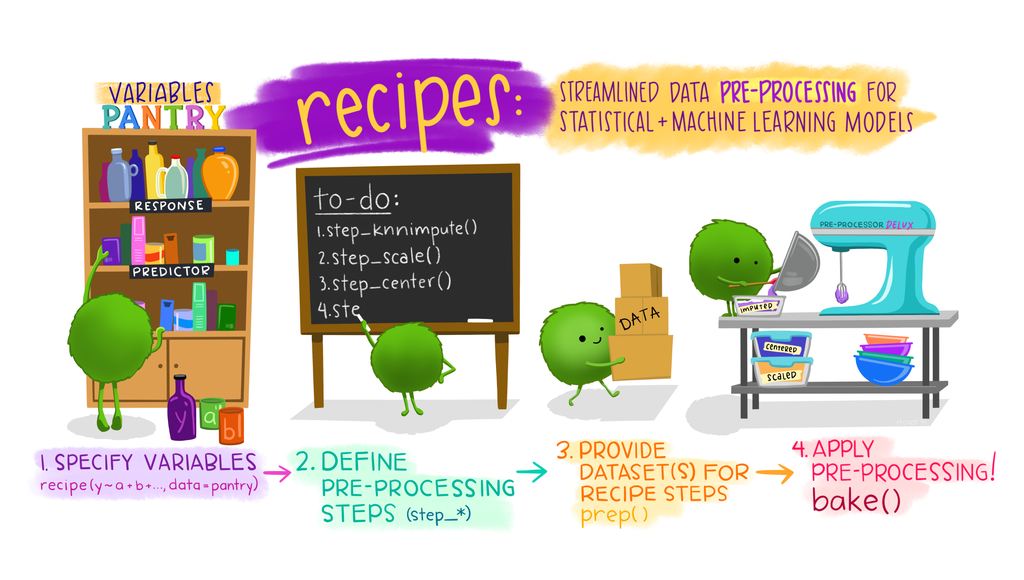

## First, We Specify the Ingredients

```r
customer_recipe <- customer_train |>
  recipe(CampaignSpend ~ PreviousSpend + Treatment + Education)
```

`recipe()` identifies the outcome and predictors (*i.e.*, the ingredients) using **formula notation**.

From here, we will add **steps** to the recipe. These are operations that will be applied to the outcome and predictors to prepare them for the model.

## Preprocessing Continuous Variables

Inspect the distributions of the outcome and continuous predictors.

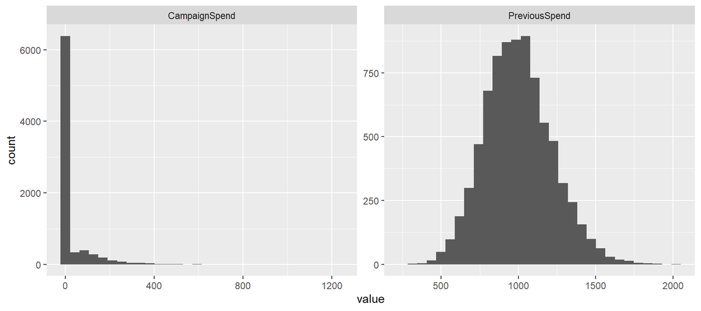

`CampaignSpend` has many zeros and a long right tail. About **80% of customers spent nothing** during the campaign window.

## Explore a Log Transformation: Code

The natural logarithm compresses large values. Its inverse is `exp()`:

\[z = \log(x + 1) \quad\Longleftrightarrow\quad x = \exp(z) - 1\]

```r
customer_train |>
  pivot_longer(
    c(CampaignSpend, PreviousSpend),
    names_to = "variable", values_to = "value"
  ) |>
  mutate(log_value = log(value + 1)) |>
  ggplot(aes(x = log_value)) +
  geom_histogram(bins = 30) +
  facet_wrap(~ variable, scales = "free")
```

## Explore a Log Transformation: Result

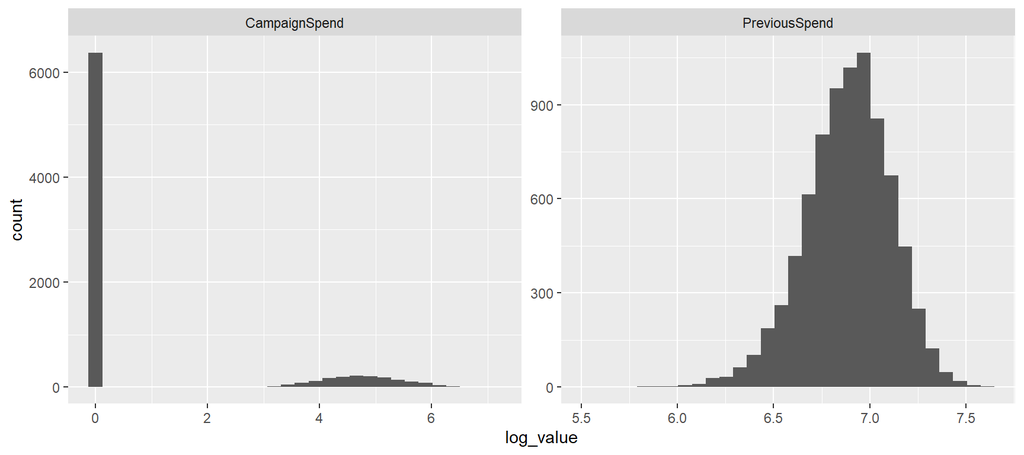

The log compresses large purchases, but the zero-spending group remains at zero. Does it improve predictions?

## Add a Log Step

```r
customer_recipe <- customer_recipe |>
  step_log(CampaignSpend, PreviousSpend, offset = 1)
```

- Name the two continuous spending variables explicitly.
- `offset = 1` adds 1 before logging, which avoids problems with \(log(0)\). All inputs must be greater than -1.

Evaluate model performance with and without a log transformation (if your outcome is skewed, log will *usually* improve model performance).

## Preprocessing Categorical Variables

`Treatment` already uses one indicator: **0 = no email, 1 = assigned email**. Keep it unchanged. Education needs multiple indicators:

| Education | Some college | Bachelor’s | Graduate |
| --- | --- | --- | --- |
| High school or less | 0 | 0 | 0 |
| Some college/associate | 1 | 0 | 0 |
| Bachelor’s | 0 | 1 | 0 |
| Graduate | 0 | 0 | 1 |

In general, if a categorical variable has \(k\) categories, your model will have \(k-1\) indicator variables for that categorical variable.

## Add Dummy Coding to the Recipe

```r
customer_recipe <- customer_recipe |>
  step_relevel(Education, ref_level = "High school or less") |>
  step_dummy(Education)
```

`step_relevel()` sets **high school or less** as the reference. `step_dummy()` then creates the other \(k-1\) indicators.

## Finalizing the Recipe

Review the steps.

```r
customer_recipe
```

```
## ── Recipe ──────────────────────────────────────────────────────────────────────
```

```
## ── Inputs
```

```
## Number of variables by role
```

```
## outcome:   1
## predictor: 3
```

```
## ── Operations
```

```
## • Log transformation on: CampaignSpend PreviousSpend
```

```
## • Re-order factor level to ref_level for: Education
```

```
## • Dummy variables from: Education
```

## Finalizing the Recipe

Once you are finished adding preprocessing steps to the recipe, you **finalize** the recipe using `prep()`.

- **`prep()`** learns data-dependent settings from training data, such as category levels or normalization means.

```r
customer_recipe <- customer_recipe |> prep()
```

## Applying the Recipe

**`bake()`** applies the prepared steps to data.

```r
baked_customer_training <- customer_recipe |>
  bake(new_data = customer_train)

baked_customer_training |> slice_head(n = 4)
```

```
## # A tibble: 4 × 6
##   PreviousSpend Treatment CampaignSpend Education_Bachelor.s Education_Graduate
##           <dbl>     <dbl>         <dbl>                <dbl>              <dbl>
## 1          6.62         0          0                       1                  0
## 2          6.97         0          4.81                    0                  0
## 3          6.87         1          0                       0                  0
## 4          6.91         0          0                       0                  1
## # ℹ 1 more variable: Education_Some.college.associate <dbl>
```

## Review Pre-Processing Workflow

1. Train-test split
2. Construct the recipe (define variables and add preprocessing steps)
3. `prep()` on **training data**
4. Use recipe to prepare (`bake()`) training, testing, and customer profiles.

Do not prepare a different recipe on testing customers or hypothetical profiles.

## Prepare the Raw Recipe

We need a recipe/model *without* the log transformation for comparison.

Use the same education reference and indicators, keeping both spending variables in dollars.

```r
raw_recipe <- customer_train |>
  recipe(CampaignSpend ~ PreviousSpend + Treatment + Education) |>
  step_relevel(Education, ref_level = "High school or less") |>
  step_dummy(Education) |>
  prep()

baked_raw_training <- bake(raw_recipe, new_data = customer_train)
```

## Fit with and without Log Transformations

```r
fit_raw <- linear_reg() |>
  set_engine("lm") |>
  fit(CampaignSpend ~ ., data = baked_raw_training)
```

```r
fit_baked <- linear_reg() |>
  set_engine("lm") |>
  fit(CampaignSpend ~ ., data = baked_customer_training)
```

`.` means all remaining columns in the baked model data.

## Isolate the Outcome Log Transformation

Develop a recipe and train a model that log transforms `CampaignSpend` only. This allows us to compare the effect of the outcome’s transformation from logging previous spending too.

```r
outcome_recipe <- customer_train |>
  recipe(CampaignSpend ~ PreviousSpend + Treatment + Education) |>
  step_log(CampaignSpend, offset = 1) |>
  step_relevel(Education, ref_level = "High school or less") |>
  step_dummy(Education) |>
  prep()

fit_outcome_log <- linear_reg() |>
  set_engine("lm") |>
  fit(CampaignSpend ~ ., data = bake(outcome_recipe, new_data = customer_train))
```

We now have three versions: **raw**, **outcome log only**, and **both spending logs**.

## Your Turn!

We have trained three models.

The home-goods retailer wants to know whether its email campaign increased spending, and how campaign-window spending differs by prior purchasing and education.

How should we compare the models to decide which one to use to answer the retailer’s questions?

Write a potential prompt for Codex describing the steps needed to compare and evaluate all three models.

## Compare Predictive Performance with MAE

Which model predicts campaign spending most accurately for the **testing customers**?

**Mean absolute error (MAE)** is the average size of the prediction errors. An MAE of $30 means predictions are off by $30 on average.

- Compare all three models on the same testing customers.
- Express every prediction in **dollars**.
- Choose the model with the **lowest MAE**.

## Predict Spending for the Testing Customers

Use the recipes already prepared on the training data.

```r
# prepare test data using the raw recipe
test_raw <- bake(raw_recipe, new_data = customer_test)
# prepare test data using recipe with both logs
test_both_logs <- bake(customer_recipe, new_data = customer_test)
# prepare test data using recipe with outcome log only
test_outcome_log <- bake(outcome_recipe, new_data = customer_test)

# generate predictions using all three models
predictions_raw <- predict(fit_raw, new_data = test_raw)
predictions_both_logs <- predict(fit_baked, new_data = test_both_logs)
predictions_outcome_log <- predict(fit_outcome_log,
                                   new_data = test_outcome_log)
```

**Important**: The raw model predicts `CampaignSpend`. The other two models predict `log(CampaignSpend + 1)`. We need to transform the log predictions back to dollars!

## Put All Predictions in Dollars

Reverse the log transformation before comparing predictions with actual spending.

```r
predictions_both_logs <- predictions_both_logs |>
  mutate(.pred = exp(.pred) - 1)

predictions_outcome_log <- predictions_outcome_log |>
  mutate(.pred = exp(.pred) - 1)
```

Raw-model predictions are already in dollars and need no conversion.

## Choose the Model with the Lowest MAE

```r
mae_comparison <- bind_rows(
  "Raw" = predictions_raw |> bind_cols(customer_test) |>
    mae(truth = CampaignSpend, estimate = .pred),
  "Outcome log only" = predictions_outcome_log |> bind_cols(customer_test) |>
    mae(truth = CampaignSpend, estimate = .pred),
  "Both spending logs" = predictions_both_logs |> bind_cols(customer_test) |>
    mae(truth = CampaignSpend, estimate = .pred),
  .id = "model"
) |>
  select(model, MAE = .estimate) |>
  arrange(MAE)

mae_comparison |> mutate(MAE = round(MAE, 2))
```

```
## # A tibble: 3 × 2
##   model                MAE
##   <chr>              <dbl>
## 1 Outcome log only    29.1
## 2 Both spending logs  29.1
## 3 Raw                 43.9
```

The **outcome-only log model** has the lowest MAE. Logging PreviousSpend adds no improvement here; the two logged versions perform almost identically.

## Refit the Selected Recipe and Model on All Customers

We have finished comparing models. Keep the selected specification and now use **all 10,000 customers** to estimate the final model.

```r
final_recipe <- customer_model_data |>
  recipe(CampaignSpend ~ PreviousSpend + Treatment + Education) |>
  step_log(CampaignSpend, offset = 1) |>
  step_relevel(Education, ref_level = "High school or less") |>
  step_dummy(Education) |>
  prep()

final_data <- bake(final_recipe, new_data = customer_model_data)
```

## Fit and Inspect the Final Model

```r
final_fit <- linear_reg() |>
  set_engine("lm") |>
  fit(CampaignSpend ~ ., data = final_data)

tidy(final_fit, conf.int = TRUE) |>
  select(term, estimate, conf.low, conf.high)
```

```
## # A tibble: 6 × 4
##   term                             estimate conf.low conf.high
##   <chr>                               <dbl>    <dbl>     <dbl>
## 1 (Intercept)                      -1.47    -1.65     -1.29
## 2 PreviousSpend                     0.00231  0.00213   0.00250
## 3 Treatment                         0.415    0.342     0.488
## 4 Education_Bachelor.s             -0.141   -0.245    -0.0360
## 5 Education_Graduate               -0.302   -0.430    -0.173
## 6 Education_Some.college.associate -0.0261  -0.123     0.0709
```

The coefficients describe **log(CampaignSpend + 1)**. PreviousSpend is still in dollars. Treatment and education indicators are still 0/1.

## Evaluate Parameter Estimates

### Horizontal Intervals

```r
tidy(final_fit, conf.int = TRUE) |>
  filter(term != "(Intercept)") |>
  ggplot(aes(y = term, x = estimate)) +
  geom_point() +
  geom_errorbar(aes(xmin = conf.low, xmax = conf.high),
                orientation = "y", width = .1) +
  geom_vline(xintercept = 0, color = "red")
```

## Evaluate Parameter Estimates

### Horizontal Intervals

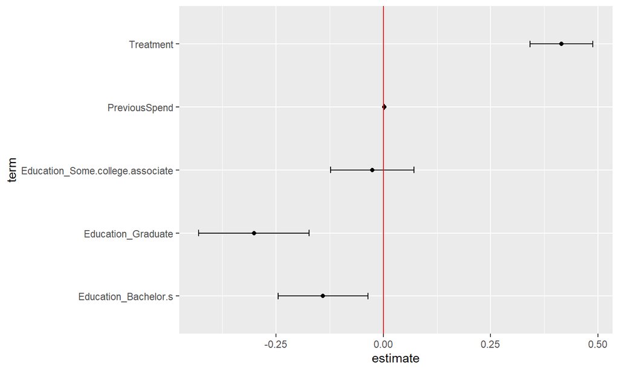

## Interpreting Slopes with Log Transformations

Hold the other predictors constant. Here, \(\beta\) is the slope coefficient for \(x\).

| Model scales | Interpretation of slope \(\beta\) |
| --- | --- |
| \(y\) and \(x\) | One more unit of \(x\): expected change in \(y\) is \(\beta\) units. |
| \(\log(y)\) and \(x\) | One more unit of \(x\): expected percentage change in \(y\) is \(100\times\beta\%\). |
| \(y\) and \(\log(x)\) | A 1% increase in \(x\): expected change in \(y\) is \(\beta/100\) units. |
| \(\log(y)\) and \(\log(x)\) | A 1% increase in \(x\): expected percentage change in \(y\) is \(\beta\%\). |

## Interpret the Final Results

Use the **log-outcome rule**: expected percentage change is approximately \(100\times\beta\%\), holding the other predictors constant.

- **PreviousSpend:** each additional $1 of previous spending corresponds to an expected change of **+0.23%**.
- **Treatment:** moving from no email (0) to email assignment (1) corresponds to an expected change of **+41.50%**.
- **Education:** compared with high school or less, the expected changes are **-2.61%** for some college/associate, **-14.06%** for bachelor’s, and **-30.17%** for graduate education.

Use the 95% confidence intervals to assess uncertainty.

## Define Customer Profiles

Combine **all four education categories**, **Treatment 0 and 1**, and previous spending of **$800, $1,000, and $1,400**: 24 customer profiles.

```r
scenarios <- expand_grid(
  PreviousSpend = c(800, 1000, 1400),
  Treatment = c(0, 1),
  Education = customer_model_data |> distinct(Education) |> pull(Education)
) |>
  mutate(CampaignSpend = 0)
```

`CampaignSpend = 0` is a placeholder required by the recipe. We remove it before prediction.

## Apply the Final Recipe and Predict

Use the **final recipe** to preprocess the profiles.

Use the **final model** to predict outcomes for the profiles.

```r
baked_scenarios <- bake(final_recipe, new_data = scenarios) |>
  select(-CampaignSpend)

profile_predictions <- bind_cols(
  scenarios |> select(-CampaignSpend),
  predict(final_fit, new_data = baked_scenarios),
  predict(final_fit, new_data = baked_scenarios, type = "pred_int")
)
```

Point predictions and 95% prediction intervals are on the log(spending + 1) scale. Convert both to dollars next.

## Read the Predictions in Dollars

```r
profile_predictions <- profile_predictions |>
  mutate(.pred = exp(.pred) - 1,
         .pred_lower = exp(.pred_lower) - 1,
         .pred_upper = exp(.pred_upper) - 1) |>
  arrange(desc(.pred))

profile_predictions |>
  slice_head(n = 6) |>
  mutate(across(c(.pred, .pred_lower, .pred_upper), ~ round(.x, 2)))
```

```
## # A tibble: 6 × 6
##   PreviousSpend Treatment Education              .pred .pred_lower .pred_upper
##           <dbl>     <dbl> <chr>                  <dbl>       <dbl>       <dbl>
## 1          1400         1 High school or less     7.83       -0.77        338.
## 2          1400         1 Some college/associate  7.6        -0.78        329.
## 3          1400         1 Bachelor's              6.67       -0.8         293.
## 4          1400         1 Graduate                5.53       -0.83        249.
## 5          1400         0 High school or less     4.83       -0.85        223.
## 6          1400         0 Some college/associate  4.68       -0.85        217.
```

All 24 profiles are ranked by predicted spending; the **six highest** are shown. The 95% prediction interval describes uncertainty in an individual customer’s spending. Negative lower limits are a limitation of this model; spending cannot be negative.

## Use the Predictions for a Targeting Decision

- **Prioritize customers with higher previous spending.** Start with customers near **$1,400 in prior annual spending**; these profiles have the highest predicted campaign spending among those compared.
- **Use a similar email to conduct targeting.** The treatment coefficient is positive. For the $1,400/high-school-or-less profile, predicted spending is **$7.83 with email versus $4.83 without**.
- **Give high-school-or-less and some-college customers higher priority than customers with higher education levels.** Customers with higher education spent approximately 14% and 30% less compared to customers with lower education levels.

## Live Coding

### Recommend a Target Group

The retailer wants a recommendation about which types of customers to target in its next email campaign.

Expand the current final model to include additional customer information and recommend a target customer profile.

## Wrapping Up

1. **Compare:** evaluate test-set MAE in dollars and choose a model.
2. **Refit and interpret:** fit that specification on all customers and examine its coefficients.
3. **Predict:** apply the final recipe and model to customer profiles, then discuss targeting implications.

*Next Time:* Integrity and Causal Inference

*Supplementary Material:* *Tidy Modeling with R*, Chapter 8.

*Artwork by @allison_horst*

## Exercise 9

### Develop a Targeting Model

The retailer wants a recommendation about which customers to target in its next email campaign.

Use **CampaignSpend** as the outcome and keep **Treatment** as a predictor. **Choose and justify additional predictors** using customer information available before the campaign. Use the data dictionary to guide your choices; do not use Conversion, which is measured during the outcome window.

**Choose preprocessing steps appropriate to your selected variables.** Use random seed 42 and a **75% training / 25% testing split**, retaining zero-spending customers. Evaluate your model choice using **test MAE in dollars**. Learn preprocessing settings and model coefficients from training data during evaluation.

## Exercise 9

### Interpret and Recommend

Refit your selected specification on **all eligible customers**. Submit a Word report rendered from Quarto with code, results, and:

- Data-cleaning decisions and sample sizes, plus reasons for your predictor and preprocessing choices and any categorical reference groups.
- Test MAE in dollars and an explanation of your final model choice.
- Final coefficients and 95% confidence intervals, with interpretations for Treatment and your selected predictors.
- Predictions and 95% individual prediction intervals in dollars for **three customer profiles of your choosing**, each with and without the email. Choose profiles that help answer your targeting question.
- A targeting recommendation supported by those predictions.

Upload the report to Canvas’s **Exercise 9** assignment.